# Assignment 9: Twitter US Airline Sentiment (NLP)

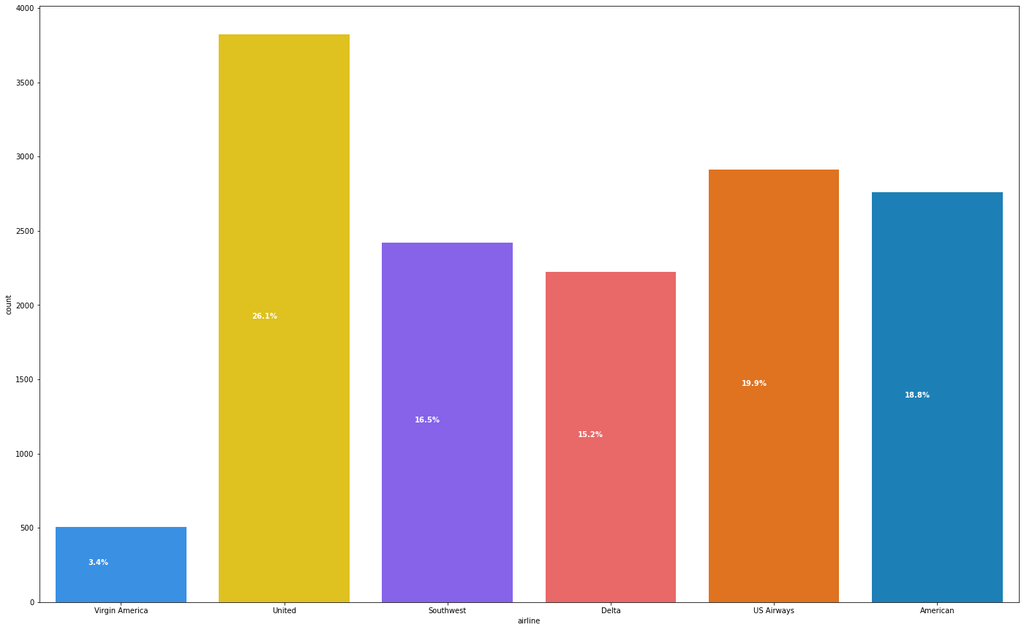

```python
PlotDataDistributionBarChartByColumn(
    df         = main_data,
    column     = "airline",
    enable_hue = False)
```

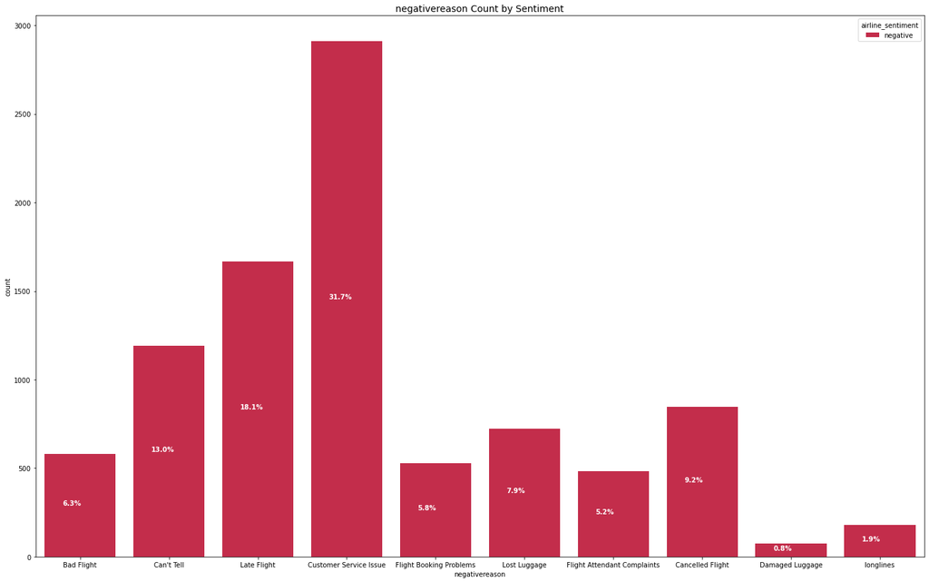

```python
PlotDataDistributionBarChartByColumn(
    df         = main_data.dropna(),
    column     = "negativereason")
```

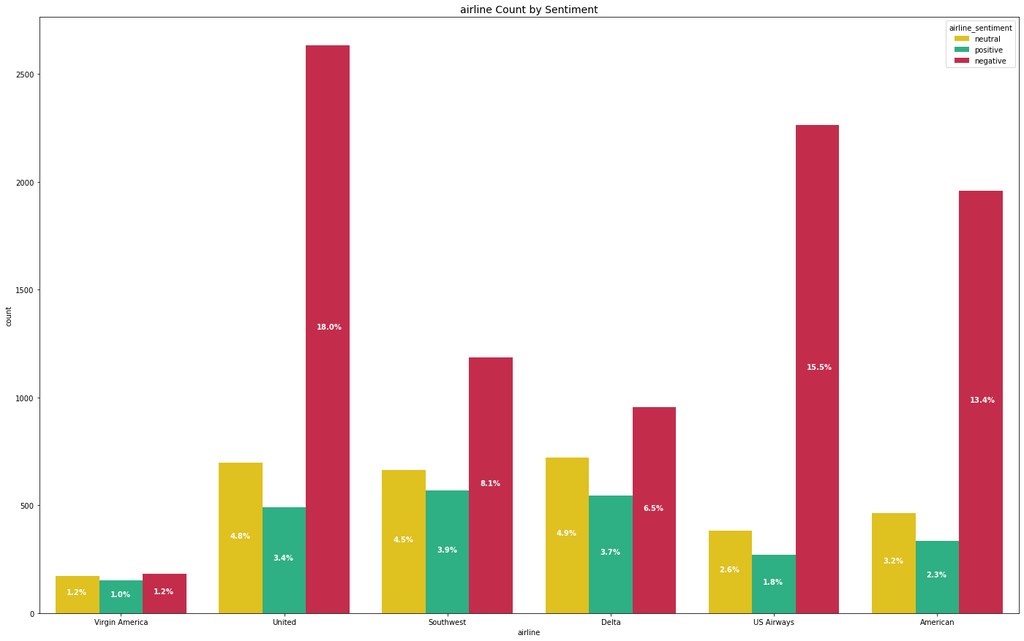

```python
PlotDataDistributionBarChartByColumn(
    df         = main_data,
    column     = "airline")
```

### Explore retweets

```python
def GetRetweetStats(df, stat):
    sentiments = df['airline_sentiment'].unique().tolist()
    stats_dfs = []
    for sentiment in sentiments:
        df_copy = df[df['airline_sentiment'] == sentiment]
        airlines = df_copy['airline'].unique().tolist()
        for airline in airlines:
            airline_stats_df = df_copy[df_copy['airline'] == airline].describe().T[[stat]]
            airline_stats_df['sentiment'] = sentiment
            airline_stats_df['airline'] = airline
            stats_dfs.append(airline_stats_df)
    return pd.concat(stats_dfs, axis=0)
```

```python
def PlotRetweetStats(df, stats_column):
    fig, ax = plt.subplots(figsize=(24,15))
    sns.barplot(x="airline", y=stats_column, data=df, palette=sentiment_color_palette, hue="sentiment", ax=ax)
    ax.set_title(f"Retweets {stats_column} by Sentiment", fontsize=14)
    ax.set_xlabel(f"airline")
    ax.set_ylabel(f"Retweets {stats_column}")

    total = 0
    for p in ax.patches:
        if p.get_height() > 0:
            total += p.get_height()

    for p in ax.patches:
        if p.get_height() > 0:
            percentage = str(((p.get_height() / total) * 100).round(1))+ '%'
            txt_x = p.get_x() + p.get_width()/4
            txt_y = p.get_height() - p.get_height()/2
            ax.text(txt_x,txt_y, percentage, color="white", weight="bold")


    plt.show()
```

```python
stat ="mean"
df = GetRetweetStats(main_data, stat)
df.sort_values(by=["airline"])
```

|  | mean | sentiment | airline |
| --- | --- | --- | --- |
| retweet_count | 0.047449 | negative | American |
| retweet_count | 0.044643 | positive | American |
| retweet_count | 0.019438 | neutral | American |
| retweet_count | 0.115183 | negative | Delta |
| retweet_count | 0.105118 | neutral | Delta |
| retweet_count | 0.121324 | positive | Delta |
| retweet_count | 0.048061 | negative | Southwest |
| retweet_count | 0.100000 | positive | Southwest |
| retweet_count | 0.046687 | neutral | Southwest |
| retweet_count | 0.091471 | negative | US Airways |
| retweet_count | 0.037175 | positive | US Airways |
| retweet_count | 0.083990 | neutral | US Airways |
| retweet_count | 0.147360 | negative | United |
| retweet_count | 0.037303 | neutral | United |
| retweet_count | 0.014228 | positive | United |
| retweet_count | 0.059211 | positive | Virgin America |
| retweet_count | 0.011050 | negative | Virgin America |
| retweet_count | 0.087719 | neutral | Virgin America |

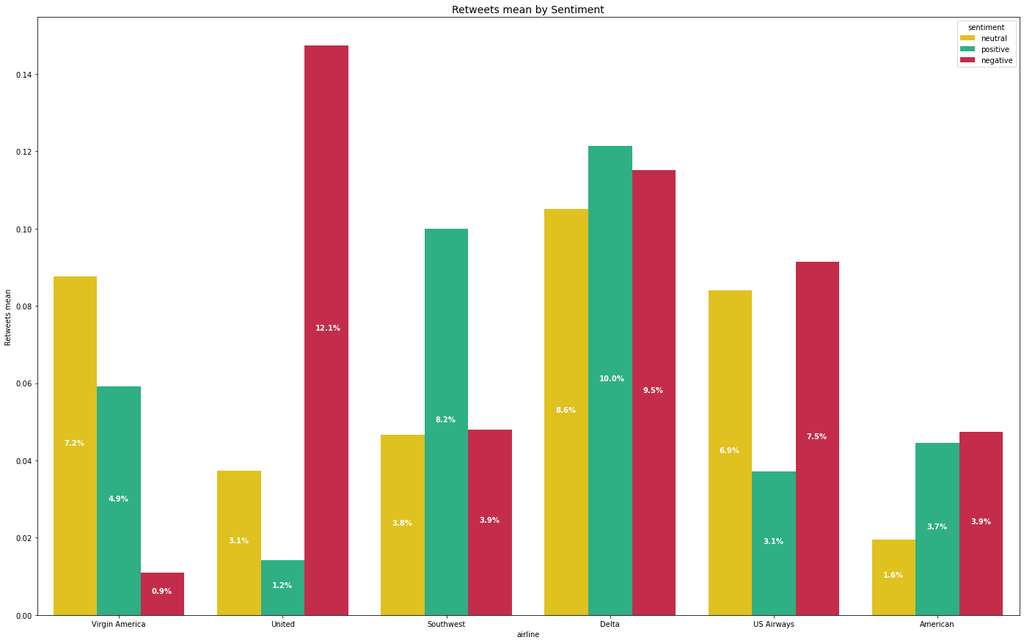

```python
PlotRetweetStats(df, stat)
```

- United has the highest number of negative retweets
- Delta seems to have consistnt high engagement regardless of the sentiment of the tweet.
- SouthWest Sees a high number of positive engagments with 8.2% in positive sentiment retweets compaired to 3.8 and 3.9 of neutral and negative sentimnts retweets respectively.

## 2. Data Pre-Processing

```python
#remove the html tags
def strip_mentiontags(text):
    return " ".join(filter(lambda x:x[0]!='@', text.split()))

#expand the contractions
def replace_contractions(text):
    """Replace contractions in string of text"""
    return contractions.fix(text)

#remove the numericals present in the text
def remove_numbers(text):
    text = re.sub(r'\d+', '', text)
    return text

def clean_text(text):
    text = strip_mentiontags(text)
    text = replace_contractions(text)
    text = remove_numbers(text)
    return text

main_data[TARGET_FEATURE] = main_data[TARGET_FEATURE].apply(lambda x: clean_text(x))
main_data.head()
```

|  | airline | text | negativereason | retweet_count | airline_sentiment |
| --- | --- | --- | --- | --- | --- |
| 0 | Virgin America | What said. | NaN | 0 | neutral |
| 1 | Virgin America | plus you have added commercials to the experie... | NaN | 0 | positive |
| 2 | Virgin America | I did not today... Must mean I need to take an... | NaN | 0 | neutral |
| 3 | Virgin America | it is really aggressive to blast obnoxious "en... | Bad Flight | 0 | negative |
| 4 | Virgin America | and it is a really big bad thing about it | Can't Tell | 0 | negative |

```python
main_data[TARGET_FEATURE] = main_data.apply(lambda row: nltk.word_tokenize(row[TARGET_FEATURE]), axis=1) # Tokenization of data
main_data.head()
```

|  | airline | text | negativereason | retweet_count | airline_sentiment |
| --- | --- | --- | --- | --- | --- |
| 0 | Virgin America | [What, said, .] | NaN | 0 | neutral |
| 1 | Virgin America | [plus, you, have, added, commercials, to, the,... | NaN | 0 | positive |
| 2 | Virgin America | [I, did, not, today, ..., Must, mean, I, need,... | NaN | 0 | neutral |
| 3 | Virgin America | [it, is, really, aggressive, to, blast, obnoxi... | Bad Flight | 0 | negative |
| 4 | Virgin America | [and, it, is, a, really, big, bad, thing, abou... | Can't Tell | 0 | negative |

```python
stop_words_common = [
    "above",
    "against",
    "aren't",
    "can't",
    "cannot",
    "could",
    "couldn't",
    "did",
    "didn't",
    "doesn't",
    "don't",
    "hadn't",
    "hasn't",
    "haven't",
    "isn't",
    "mustn't",
    "no",
    "not",
    "off",
    "shan't",
    "should",
    "shouldn't",
    "too",
    "under",
    "up",
    "very",
    "wasn't",
    "weren't",
    "which",
    "while",
    "who",
    "who's",
    "won't",
    "would",
    "wouldn't"]
```

```python
#remove the non-ASCII characters
def remove_non_ascii(words):
    """Remove non-ASCII characters from list of tokenized words"""
    new_words = []
    for word in words:
        new_word = unicodedata.normalize('NFKD', word).encode('ascii', 'ignore').decode('utf-8', 'ignore')
        new_words.append(new_word)
    return new_words

# convert all characters to lowercase
def to_lowercase(words):
    """Convert all characters to lowercase from list of tokenized words"""
    new_words = []
    for word in words:
        new_word = word.lower()
        new_words.append(new_word)
    return new_words

# Remove the punctuations
def remove_punctuation(words):
    """Remove punctuation from list of tokenized words"""
    new_words = []
    for word in words:
        new_word = re.sub(r'[^\w\s]', '', word)
        if new_word != '':
            new_words.append(new_word)
    return new_words

# Remove the stop words
def remove_stopwords(words):
    """Remove stop words from list of tokenized words"""
    stopwords_local = list(set(stopwords)-set(stop_words_common))
    new_words = []
    for word in words:
        if word not in stopwords_local:
            new_words.append(word)
    return new_words

# lemmatize the words
def lemmatize_list(text):
    words = ' '.join(text)
    text = nlp(words)
    words = [word.lemma_ if word.lemma_ != '-PRON-' else word.text for word in text]
    return words

def normalize(words):
    words = remove_non_ascii(words)
    words = to_lowercase(words)
    words = remove_punctuation(words)
    words = remove_stopwords(words)
    words = lemmatize_list(words)
    return ' '.join(words)
```

```python
main_data[TARGET_FEATURE] = main_data.apply(lambda row: normalize(row[TARGET_FEATURE]), axis=1)
main_data.head(10)
```

|  | airline | text | negativereason | retweet_count | airline_sentiment |
| --- | --- | --- | --- | --- | --- |
| 0 | Virgin America | say | NaN | 0 | neutral |
| 1 | Virgin America | plus add commercial experience tacky | NaN | 0 | positive |
| 2 | Virgin America | do not today must mean need take another trip | NaN | 0 | neutral |
| 3 | Virgin America | really aggressive blast obnoxious entertainmen... | Bad Flight | 0 | negative |
| 4 | Virgin America | really big bad thing | Can't Tell | 0 | negative |
| 5 | Virgin America | seriously would pay flight seat do not play re... | Can't Tell | 0 | negative |
| 6 | Virgin America | yes nearly every time fly vx ear worm not go away | NaN | 0 | positive |
| 7 | Virgin America | really miss prime opportunity man without hat ... | NaN | 0 | neutral |
| 8 | Virgin America | well do notbut | NaN | 0 | positive |
| 9 | Virgin America | amazing arrive hour early too good | NaN | 0 | positive |

```python
def PlotWordCloud(df, sentiment):
    sentiment_data = df[df['airline_sentiment'] == sentiment]
    words = ' '.join(sentiment_data['text'])
    cleaned_word = " ".join([word for word in words.split()])
    wordcloud = WordCloud(stopwords=STOPWORDS,
                          background_color='black',
                          width=2500,
                          height=2500
                         ).generate(cleaned_word)
    plt.figure(1,figsize=(12, 12))
    plt.imshow(wordcloud)
    plt.axis('off')
    plt.title(
        f"[Sentiment={sentiment}]",
        fontdict={
            'fontsize': "xx-large",
            'fontweight' : "bold"})
    plt.show()
```

### Nuetral Sentiment Text Word Cloud

- Cannot deduce any sentiment from the words in this visualisation. Maybe if some words were grouped together like "late" and "flight" as "lateflight" we could then make an inference of the sentiment. Otherwise the words in this word cloud dont seem negative or positive just neutral.

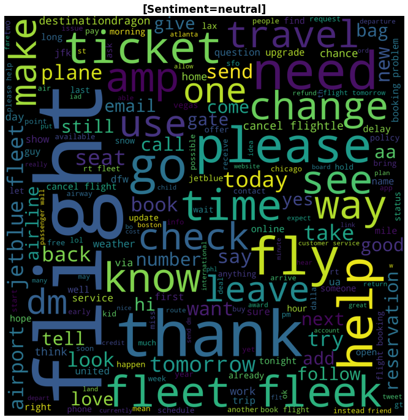

```python
PlotWordCloud(main_data, "neutral")
```

### Negative Sentiment Text Word Cloud

- Again here flight seem to be the most occuring word, we see bag too, "customer" and "service" placed in juxtaposition to each other makes it consticous/aparent easy to spot "customer service" as a negative sentiment since the words are in the same color and size implying they were occuring together in almost every text.
- Similarly to "customer service" we see "cancel flight" too

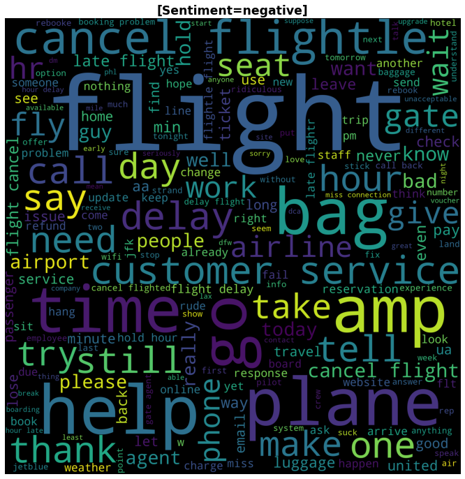

```python
PlotWordCloud(main_data, "negative")
```

### Positive Sentiment Text Word Cloud

- "customer service" also apears to be one of the positive sentiment indicator, we see "awesome" too, "love", and "great"

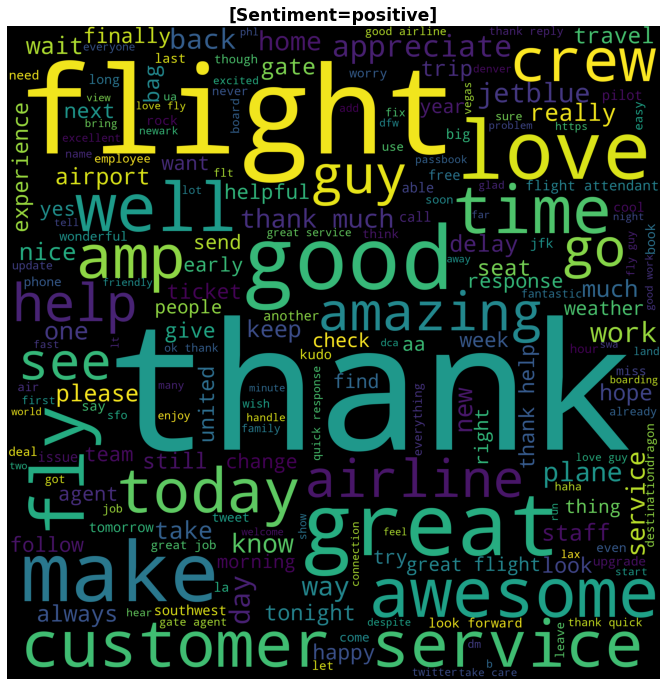

```python
PlotWordCloud(main_data, "positive")
```

### Encode Sentiment Column

```python
replace_struct = {
    "airline_sentiment" : {"neutral": 0, "negative": 1, "positive": 2},
}
main_data = main_data.replace(replace_struct)
main_data["airline_sentiment"] = pd.to_numeric(main_data["airline_sentiment"], downcast="integer")
```